# Applied statistical testing for DM

#### 7.2 Erori de tipul I

Daca p-value este mai mica decat α, se respinge afirmatia nula. Daca H0 este de fapt adevarata, valoarea lui α defineste in mod direct probabilitatea faptului ca afirmatia a fost incorect respinsa. Acest fenomen este definit ca o eroare de tipul I.

Figura urmatoare prezinta o ilustratie conceptuala a probabilitatii de aparitie a unei astfel de erori pentru o presupusa ipoteza de testare pentru o proba medie, unde ipotezele sunt puse ca **H0 : µ = µ0 si HA : µ > µ0**.

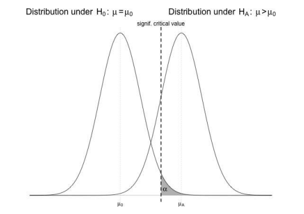

Distributia ipotezei nule este centrata pe valoarea nula µ0, distributia ipotezei alternative este centrata la dreapta la o valoare µA medie. Dupa cum se observa, daca afirmatia nula este adevarata, atunci probailitatea ca aceasta sa fie incorect respinsa pentru testul de mai sus este egala cu significanta predefinita la nivelul lui α, pozitionata la coada superioara a distributiei lui H0.

##### **Simularea erorilor de Tipul I**

Pentru a demonstra rata de aparitie a erorii de tip I printr-o simulare numerica, se poate scrie cod care produce echivalentul repetarii unei ipoteze de testare in conditii cunoscute:

```r
typeI.tester <- function(mu0,sigma,n,alpha,ITERATIONS=10000){
pvals <- rep(NA,ITERATIONS)
for(i in 1:ITERATIONS){
temporary.sample <- rnorm(n=n,mean=mu0,sd=sigma)
temporary.mean <- mean(temporary.sample)
temporary.sd <- sd(temporary.sample)
pvals[i] <- 1-pt((temporary.mean-mu0)/(temporary.sd/sqrt(n)),df=n-1)
}
return(mean(pvals<alpha))
}
```

Functia **typeI.tester** genereaza un numar de probe egal cu valoarea variabilei ITERATIONS dintr-o distributie normala particulara. Cu fiecare proba, se produce un test de medie de tip coada superioara, presupunand ipotezele: **H0 : µ = µ0 si HA : µ > µ0**.

Se poate scadea valoarea variabilei ITERATIONS pentru a genera mai putine probe complete, scazand timpul de computare dar va rezulta in rezultate simulate care sunt mai variabile. Fiecare proba de dimensiune n a unei ipoteze de masurare bruta este generata folosind **rnorm** cu media egala cu argumentul mu0 (si deviatia standard egala cu argumentul sigma). Nivelul de significanta dorit este setat de alfa. In instructiunea for, media probelor si deviatia standard se calculeaza pentru fiecare proba generata.

Daca fiecare proba era trecuta printr-o ipoteza de testare “reala”, p-value era luata din partea dreapta a distributiei t cu n-1 grade de libertate.

Rularea functiei **typeI.tester**:

```r
typeI.tester(mu0=0,sigma=1,n=40,alpha=0.05)
```

```
## [1] 0.0471
```

Se da un alt exemplu, de data aceasta folosindu-se o valoare α = 0.01:

```r
typeI.tester(mu0=-4,sigma=0.3,n=60,alpha=0.01)
```

```
## [1] 0.0102
```

Observam ca, din nou, rata erorii simulate numeric de tip I reflecta significantul de nivel.

##### **Corectia Bonferroni**

Faptul ca eroarea de tip I se produce in mod natural din cauza unei variatii aleatorii este in particular importanta si conduce la considerarea aparitiei unor multiple probleme de testare. Daca se conduc multe ipoteze de testare, trebuie abordat cu grija momentul in care se raporteaza “numarul de rezultate signifiante din punct de vedere statistic” – cu cat creste numarul de ipoteze de testare, cu atat mai mult cresc sansele de a obtine un rezultat eronat. De exemplu, din 20 de teste rulate cu α = 0.05, in medie unul va fi un asa-numit fals pozitiv; daca se ruleaza 40 sau 60 de teste, este mult mai probabil sa se intalneasca rezultate fals-pozitive.

Cand mai multe ipoteze de testare sunt efectuate, se poate limita problema testarii multiple ,care conduce la aparitia unei erori de tip I, folosind corectarea Bonferroni. Corectarea Bonferroni sugereaza ca la efectuarea unui total de N ipoteze de testare independente, fiecare cu o significanta de nivel alfa, sa se foloseasca in schimb relatia αB = α/N pentru orice interpretare a unei significante statistice. Se atrage atentia ca aceasta corectare la significantul de nivel reprezinta cea mai usoara solutie pentru problema testelor multiple si poate fi criticata pentru natura sa conservatoare, care poate fi problematica atunci cand N are o valoare mare.

#### 7.3 Erori de tipul II

Problema cu erorile de tip I sugereaza ca este dorit sa se produca o ipoteza de testare cu o valoare α mai mica. Din pacate, nu este tot timpul atat de simplu: reducerea significantului de nivel pentru fiecare test dat duce direct la cresterea in sansa de a intalni o eroare de tip II.

O eroare de tip II se refera la retinerea in mod incorect a ipotezei nule – cu alte cuvinte, obtinerea unui p-value mai mare decat significantul de nivel cand ipoteza alternativa este cea adevarata. Probabilitatea de aparitie a unei Erori de Tip II se noteaza cu β.

Nu este atat de usor de gasit β precum este de a gasi probabilitatea de a se produce o eroare de tipul I pentru ca β depinde, pe langa alti factori, de valoarea adevar a lui µA (care in general este necunoscuta). Daca µA este mai aproape de valoarea ipotetica nula a lui µ0, ne putem imagina translatarea distributiei alternative catre stanga, care rezulta intr-o crestere a lui β.

Similar, se poate imagina scaderea significantului de nivel α. Facand asta, valorarea critica se muta la dreapta, crescand astfel suprafata lui β. Intuitiv, acest lucru are sens – cu cat este mai aproape valoarea reala alternativa fata de null si/sau mai mica decat significantul de nivel, cu atat este mai greu sa se gaseasca HA prin respingerea lui H0.

Daca se presupune ca se stie σ, distributia probelor de interes va fi normala cu media µ0 = 0 si cu o eroare standard de 1/√30. Astfel, cu aria cozii superioare de 0.05, se poate gasi valoarea critica folosind urmatorul cod:

```r
critval <- qnorm(1-0.05,mean=0,sd=1/sqrt(30))
critval
```

```
## [1] 0.3003078
```

Eroarea de tip II in acest exemplu este gasita in zona din stanga a cozii, sub distributia alternativa “adevarata”, din valoarea critica:

```r
pnorm(critval,mean=0.5,sd=1/sqrt(30))
```

```
## [1] 0.1370303
```

Din acest exemplu, se poate observa ca o ipoteza de testare in aceste conditii are aproximativ 13.7% sanse de a retine incorect ipoteza nula.

##### **Simularea erorilor de Tipul II**

Simularea este in particular folositoare aici. Putem defini urmatoarea functie **typeII.tester**:

```r
typeII.tester <- function(mu0,muA,sigma,n,alpha,ITERATIONS=10000){
pvals <- rep(NA,ITERATIONS)
for(i in 1:ITERATIONS){
temporary.sample <- rnorm(n=n,mean=muA,sd=sigma)
temporary.mean <- mean(temporary.sample)
temporary.sd <- sd(temporary.sample)
pvals[i] <- 1-pt((temporary.mean-mu0)/(temporary.sd/sqrt(n)),df=n-1)
}
return(mean(pvals>=alpha))
}
```

Aceasta functie este asemanatoare cu typeI.tester, diferenta consta in faptul ca typeII.tester are in plus mediata “adevarata” µA, prin care se genereaza probele.

Putem simula probabilitatea de aparitie a unei erori de Tip II (β) astfel:

```r
typeII.tester(mu0=0,muA=0.5,sigma=1,n=30,alpha=0.05)
```

```
## [1] 0.1499
```

Rezultatul indica o valoare apropiata de valoarea teoretica β evaluata anterior, desi putin mai mare din cauza incertitudinii care este prezenta in mod natural cand se foloseste distributia de probe de tipul t in loc de o normala. Din nou, **de fiecare data cand se ruleaza tipeII.tester, rezultatele vor varia putin, avand in vedere faptul ca functia este bazata pe probe de date ipotetice generate aleatoriu**.

Prin rularea typeII.tester cu un nivel de significanta mai mic, observam ca probabilitatea aparitiei unei erori de tip II creste:

```r
typeII.tester(mu0=0,muA=0.5,sigma=1,n=30,alpha=0.01)
```

```
## [1] 0.3896
```

##### **Alte influente asupra probabilitatii de eroare de Tipul II**

Significantul de nivel nu este singurul factor ce contribuie la aparitia β. Mentinandu-se α la 0.01, se va observa ce se intampla daca deviatia standard a masuratorilor brute creste de la σ = 1 la σ = 1.1 si apoi pana la σ = 1.2:

```r
typeII.tester(mu0=0,muA=0.5,sigma=1.1,n=30,alpha=0.01)
```

```
## [1] 0.4717
```

```r
typeII.tester(mu0=0,muA=0.5,sigma=1.2,n=30,alpha=0.01)
```

```
## [1] 0.5634
```

Marind variabilitatea masuratorilor, fara sa se schimbe nicio alta valoare, creste sansa de aparitie a unei erori de tip II. Invers, daca variabilitatea masuratorilor brute este mai mica, distributiile de probe vor arata o reducere a lui β.

```r
typeII.tester(mu0=0,muA=0.5,sigma=1.2,n=20,alpha=0.01)
```

```
## [1] 0.7177
```

```r
typeII.tester(mu0=0,muA=0.5,sigma=1.2,n=40,alpha=0.01)
```

```
## [1] 0.4107
```

In final, un alt factor care afecteaza β il reprezinta valoarea µA. Din nou, retinand valorile cele mai recente pentru toate celelalte componente, β va avea valori mai mari atunci cand µA se apropie de µ0 si invers, valori mai mici atunci cand µA creste.

```r
typeII.tester(mu0=0,muA=0.4,sigma=1.2,n=40,alpha=0.01)
```

```
## [1] 0.6148
```

```r
typeII.tester(mu0=0,muA=0.6,sigma=1.2,n=40,alpha=0.01)
```

```
## [1] 0.2445
```

In concluzie, desi probabilitatea de aparitie a unei erori de tip II a fost simulata, conceptele generale discutate sunt valabile pentru orice ipoteza. Este usor de afirmat ca probabilitatea erorii de tip I se potriveste cu significantul de nivel si poate fi scazuta prin reducerea valorii lui α. In contrast, controlarea probabilitatii erorii de tip II este un procedeu mai greu de echilibrat care implica dimensiunea datelor de esantionare, significantul de nivel, variabilitatea de observatie si magnitudinea diferentei dintre valoarea reala si cea nula. Problema aceasta este prezenta strict la nivel academic deoarece “adevarul” este necunoscut in practica. Totusi, legatura dintre probabilitatea erorii de tip II si puterea statistica joaca un rol important in pregatirea pentru colectarea datelor, mai ales cand se considera cerintele dimensiunii probelor.

#### Exercitiul 7

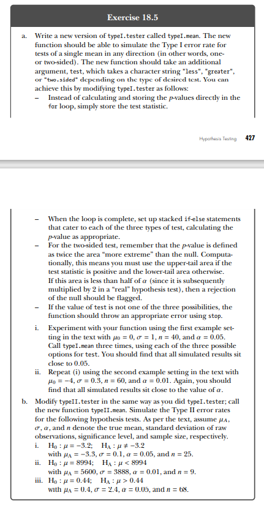

#### Exercitiul 7 - Rezolvare

```r
# a

typeI.mean<-function(mu0,sigma,n,alpha,ITERATIONS=10000,test="less"){
      t.stat<-rep(NA,ITERATIONS)
      pvals<-rep(NA,ITERATIONS)
      for(i in 1:ITERATIONS){
            temporary.sample<-rnorm(n=n,mean=mu0,sd=sigma)
            temporary.mean<-mean(temporary.sample)
            temporary.sd<-sd(temporary.sample)
            t.stat[i]<-(temporary.mean-mu0)/(temporary.sd/sqrt(n))
      }
      if(test=="less"){
        pvals<-pt(t.stat,df=n-1)
      }else
            if(test=="greater"){
            pvals<-1-pt(t.stat,df=n-1)
      }else
            if(test=="two.sided"){
            pvals[t.stat>=0]<-2*(1-pt(t.stat[t.stat>=0],df=n-1))
            pvals[t.stat<0]<-2*pt(t.stat[t.stat<0],df=n-1)

            }else {
            stop("test nu e valid. Foloseste \"less\",\"greater\",or \"two.sided\"")
      }
      return(mean(pvals<alpha))
}

# i

typeI.mean(0,1,40,0.05,test="less")
```

```
## [1] 0.0532
```

```r
typeI.mean(0,1,40,0.05,test="greater")
```

```
## [1] 0.0486
```

```r
typeI.mean(0,1,40,0.05,test="two.sided")
```

```
## [1] 0.0512
```

```r
# ii

typeI.mean(-4,0.3,60,0.01,test="less")
```

```
## [1] 0.0109
```

```r
typeI.mean(-4,0.3,60,0.01,test="greater")
```

```
## [1] 0.0105
```

```r
typeI.mean(-4,0.3,60,0.01,test="two.sided")
```

```
## [1] 0.0089
```

```r
# b

typeII.mean<-function(mu0,muA,sigma,n,alpha,test="two.sided",ITERATIONS=10000){
      test.t<-rep(NA,ITERATIONS)
      for(i in 1:ITERATIONS){
            temporary.sample<-rnorm(n=n,mean=muA,sd=sigma)
            temporary.mean<-mean(temporary.sample)
            temporary.sd<-sd(temporary.sample)
            test.t[i]<-(temporary.mean-mu0)/(temporary.sd/sqrt(n))
      }
      pvals<-pt(test.t,df=n-1)
      if(test=="less"){
            return(mean(pvals>=alpha))
      }else if(test=="greater"){
            return(mean(1-pvals>=alpha))
      }else if(test=="two.sided"){
            result <- pvals
            result[test.t>0] <- 1-pvals[test.t>0]
            return(mean(result>=alpha/2))
      }else {
            stop("\"test\" nu e valid. Foloseste \"less\", \"greater\" or \"two.sided\"")
      }
}

#i

typeII.mean(-3.2,-3.3,0.1,25,0.05,"two.sided")
```

```
## [1] 0.0028
```

```r
#ii

typeII.mean(8994,5600,3888,9,0.01,"less")
```

```
## [1] 0.554
```

```r
#iii

typeII.mean(0.44,0.4,2.4,68,0.05,"greater")
```

```
## [1] 0.9607
```

#### 7.4 Puterea statistica

Pentru orice test de ipoteza, este util sa se ia in considerare puterea statistică potențială a acestuia. Puterea este probabilitatea de a respinge corect o ipoteză nulă care nu este adevărată. Pentru un test care are o rată de eroare de Tip II egala cu β, puterea statistică se calculează pur și simplu cu: 1 - β. Este de dorit ca un test să aibă o putere care să fie cât mai mare. Din simpla relatie cu probabilitatea de eroare de Tip II, deducem că toți factorii care influențează valoarea lui β afectează, de asemenea, în mod direct puterea.

Prin convenție, un test de ipoteză care are o putere mai mare de 0,8 este considerat puternic din punct de vedere statistic.

Putem evalua numeric puterea prin simularea anumitor conditii de testare.

##### **Simularea Puterii**

In cadrul exemplului, vom defini functia **power.tester** care ne va spune cu cat trebuie marit gradul de esantionare (n) pentru a avea un test puternic din punct de vedere statistic:

```r
power.tester <- function(nvec,...){
nlen <- length(nvec)
result <- rep(NA,nlen)
for(i in 1:nlen){
result[i] <- 1-typeII.tester(n=nvec[i],...)
}
return(result)
}
```

Functia **power.tester** primeste ca parametru vectorul marimilor esantioanelor **nvec**, iar cu un ciclu for se itereaza prin elementele lui nvec iterativ, simuland puterea fiecarei marimi de esationare. Puterile calculate sunt stocate intr-un vector rezultat care este intors de functie.

**De mentionat faptul ca functia power.tester se foloseste la randul sau de functia typeII.tester. Aceasta genereaza aleator valori ipotetice de esantionare, deci pot exista fluctuatii in rezultatele intoarse la fiecare rulare a functiei power.tester.**

Pentru exemplificarea functiei **power.tester**, vom crea intai vectorul *nvec*:

```r
sample.sizes <- 5:100
sample.sizes
```

```
##  [1]   5   6   7   8   9  10  11  12  13  14  15  16  17  18  19  20  21  22  23
## [20]  24  25  26  27  28  29  30  31  32  33  34  35  36  37  38  39  40  41  42
## [39]  43  44  45  46  47  48  49  50  51  52  53  54  55  56  57  58  59  60  61
## [58]  62  63  64  65  66  67  68  69  70  71  72  73  74  75  76  77  78  79  80
## [77]  81  82  83  84  85  86  87  88  89  90  91  92  93  94  95  96  97  98  99
## [96] 100
```

Rularea functiei **power.tester** pe dimensiunile de esantionare generate, folosind un numar de iteratii egal cu 5000:

```r
pow <- power.tester(nvec=sample.sizes,
mu0=0,muA=0.6,sigma=1.2,alpha=0.01,ITERATIONS=5000)
pow
```

```
##  [1] 0.0582 0.0800 0.0994 0.1164 0.1450 0.1634 0.1842 0.1954 0.2450 0.2484
## [11] 0.2788 0.3056 0.3208 0.3546 0.3700 0.3964 0.4338 0.4592 0.4658 0.4978
## [21] 0.5050 0.5376 0.5492 0.5702 0.5920 0.6216 0.6270 0.6410 0.6698 0.6752
## [31] 0.7088 0.7236 0.7346 0.7336 0.7608 0.7692 0.7826 0.7886 0.8030 0.8110
## [41] 0.8270 0.8318 0.8388 0.8518 0.8542 0.8624 0.8780 0.8838 0.8952 0.8934
## [51] 0.9028 0.9016 0.9224 0.9168 0.9264 0.9284 0.9316 0.9336 0.9430 0.9450
## [61] 0.9520 0.9550 0.9512 0.9564 0.9600 0.9606 0.9656 0.9676 0.9690 0.9672
## [71] 0.9732 0.9750 0.9778 0.9810 0.9798 0.9814 0.9780 0.9836 0.9820 0.9864
## [81] 0.9882 0.9870 0.9870 0.9890 0.9890 0.9932 0.9920 0.9914 0.9928 0.9908
## [91] 0.9930 0.9934 0.9950 0.9952 0.9974 0.9952
```

```r
minimum.n <- sample.sizes[min(which(pow>=0.8))]
minimum.n
```

```
## [1] 43
```

Vom simula acelasi test in aceleasi conditii, schimband doar nivelul de significanta (alpha). Daca vom folosi alpha = 0.05 in loc de alpha = 0.01 (valoarea din simularea anterioara), valoarea critica ar fi mutata la stanga, scazand astfel β si ducand la cresterea puterii. Cu alte cuvinte, marimea gradului de esantionare necesar atingerii pragului de 80% (pentru un test puternic statistic), ar scadea. Ne asteptam sa obtinem un n < 43 pentru aceasta simulare:

```r
pow2 <- power.tester(nvec=sample.sizes,
mu0=0,muA=0.6,sigma=1.2,alpha=0.05,ITERATIONS=5000)
minimum.n2 <- sample.sizes[min(which(pow2>0.8))]
minimum.n2
```

```
## [1] 27
```

Observam obtinerea unei valori n = 27 pentru simularea cu alpha = 0.05, reprezentand o reducere semnificativa de la simularea initiala prin care s-a obtinut o marime minima de esantionare n = 43. Totusi, aceasta relaxare a lui alpha creste riscul savarsirii unei erori de Tip I.

##### **Curbe de Putere**

Pentru compararea grafica a celor doua simulari, vom folosi urmatoarea bucata de cod:

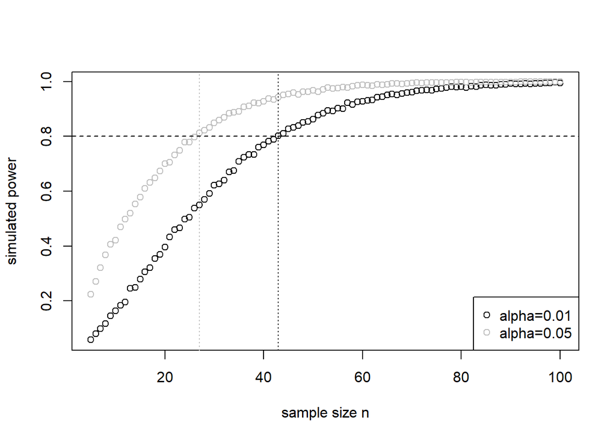

```r
plot(sample.sizes,pow,xlab="sample size n",ylab="simulated power")
points(sample.sizes,pow2,col="gray")
abline(h=0.8,lty=2)
abline(v=c(minimum.n,minimum.n2),lty=3,col=c("black","gray"))
legend("bottomright",legend=c("alpha=0.01","alpha=0.05"),
col=c("black","gray"),pch=1)
```

Putem concluziona discutia despre erori si putere prin evidentierea necesitatii de a interpreta rezultatele cu atentie. O valoare p-value este doar o probabilitate si, ca atare, indiferent de cat de mica ar putea fi în orice circumstanță, nu poate niciodată să dovedească sau să infirme o afirmație de una singură. Aspectele legate de calitatea unui test de ipoteză (parametric sau de altă natură) ar trebui să fie luate în considerare, deși acest lucru este, fără îndoială, dificil în practică. Cu toate acestea, o conștientizare a erorilor de tip I și de tip II, precum și a conceptului de puterea statistică, este extrem de utilă în punerea în aplicare și în evaluarea oricărei proceduri formale de testare statistică.

#### Exercitiul 8

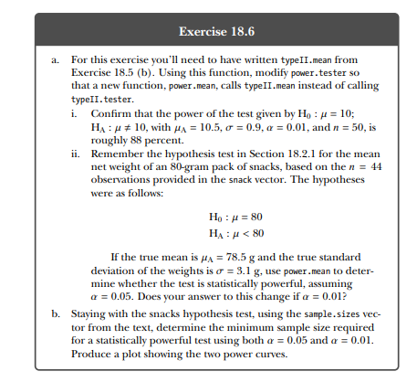

#### Exercitiul 8 - Rezolvare

```r
# a

power.mean<-function(nvec,...){
      nlen<-length(nvec)
      result<-rep(NA,nlen)
      for(i in 1:nlen){
            result[i]<-1-typeII.mean(n=nvec[i],...)
      }
      return(result)
}

# i

sample.sizes=5:100
power.mean(nvec=50,mu0=10,muA=10.5,sigma=0.9,alpha=0.01,test="two.sided")
```

```
## [1] 0.8899
```

```r
# ii

power.mean(nvec=44,mu0=80,muA=78.5,sigma=3.1,alpha=0.05,test="two.sided")
```

```
## [1] 0.8799
```

```r
power.mean(nvec=44,mu0=80,muA=78.5,sigma=3.1,alpha=0.01,test="two.sided")
```

```
## [1] 0.7083
```

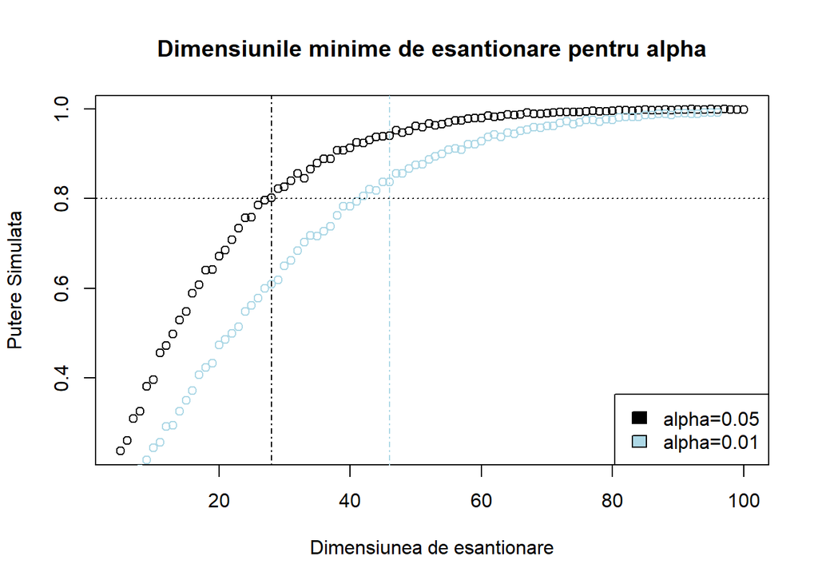

```r
# b

snacks <- c(87.7,80.01,77.28,78.76,81.52,74.2,80.71,79.5,77.87,81.94,80.7,82.32,
            75.78,80.19,83.91,79.4,77.52,77.62,81.4,74.89,82.95,73.59,77.92,
            77.18,79.83,81.23,79.28,78.44,79.01,80.47,76.23,78.89,77.14,69.94,
            78.54,79.7,82.45,77.29,75.52,77.21,75.99,81.94,80.41,77.7)

sample.sizes<- 5:100

pow1 <- power.mean(
      nvec = sample.sizes,
      mu0 = 80,
      muA = 78.5,
      sigma = 3.1,
      alpha = 0.05,
      ITERATIONS = 5000,
      test = "less"
)

pow2 <- power.mean(
      nvec = sample.sizes,
      mu0 = 80,
      muA = 78.5,
      sigma = 3.1,
      alpha = 0.01,
      ITERATIONS = 5000,
      test = "less"
)

min.1<-sample.sizes[min(which(pow1>0.8))]
min.2<-sample.sizes[min(which(pow2>0.8))]

plot(sample.sizes,pow1,main="Dimensiunile minime de esantionare pentru alpha",xlab="Dimensiunea de esantionare",ylab="Putere Simulata")
points(pow2,col="lightblue")
abline(h=0.8,lty=3)
abline(v=min.1,lty=4)
abline(v=min.2,lty=4,col="lightblue")
legend("bottomright",legend=c("alpha=0.05","alpha=0.01"),fill=c("black","lightblue"))
```

## 8. One-Way ANOVA

Analiza varianței (ANOVA) este o metodă statistică utilizată pentru a testa dacă există o diferență semnificativă între mai multe medii de grupuri. Ea permite compararea mai multor grupuri simultan și determină dacă există cel puțin o diferență între ele.

Există mai multe tipuri de ANOVA, cea mai simpla fiind ANOVA de un singur factor. Aceasta este utilizată pentru a compararea mai multor grupuri cu privire la o singura variabila. De exemplu, ANOVA poate fi folosita pentru a determina diferentele dintre greutatile unor grupuri de pui de gaina (setul de date *chickwts*) care au fost hranite cu tipuri diferite de mancare.

#### 8.1 Ipoteze si verificarea diagnosticului

Verificarea diagnosticului implică testarea ipotezei prin colectarea și analizarea datelor empirice. Dacă datele colectate sprijină ipoteza, aceasta este considerată a fi validată. Dacă datele nu sprijină ipoteza, aceasta este considerată a fi respinsă.

În general, în statistică, se folosește un nivel de significanță pentru a determina dacă datele sunt suficient de puternice pentru a respinge ipoteza nullă (ipoteza că nu există diferență sau relație între variabilele studiate). Nivelul de significanță este un prag care se stabilește înainte de colectarea datelor și care indică probabilitatea de a obține rezultatele observate întâmplător dacă ipoteza nullă este adevărată. Dacă probabilitatea este mai mică decât nivelul de significanță stabilit, se respinge ipoteza nullă și se acceptă ipoteza alternativă (ipoteza că există o diferență sau o relație între variabile).

Urmatoarele presupuneri trebuie validate pentru ca rezultatele unui test ANOVA one-way sa fie de incredere:

- **Independenta** - Datele din cele k grupuri trebuie sa fie independente intre ele si observatiile din fiecare grup trebuie sa fie independente si identic distribuite.
- **Normalitatea** - Observatiile din fiecare grup ar trebui sa fie normal distribuite sau cel putin sa fie aproximativ normal distribuite.
- **Egalitatea variatiilor** - Variatia observatiilor din fiecare grup ar trebui sa fie egala sau cel putin aproximativ egala.

Daca presupunerile de normalitate sau de egalitate a variatiilor sunt incalcate, nu inseamna neaparat ca rezultatele testului sunt inutile, ci ca este afectata eficienta de a detecta o diferenta reala intre medii.

Revenind la exemplul anterior cu greutatile puilor de gaina (setul de date *chickwts*), vom compara mediile greutatilor a 6 grupuri pui, fiecare grup fiind hranit cu un alt tip de mancare (k = 6), pentru a vedea daca acestea sunt egale:

```r
table(chickwts$feed)
```

```
##
##    casein horsebean   linseed  meatmeal   soybean sunflower
##        12        10        12        11        14        12
```

```r
chick.means <- tapply(chickwts$weight,INDEX=chickwts$feed,FUN=mean)
chick.means
```

```
##    casein horsebean   linseed  meatmeal   soybean sunflower
##  323.5833  160.2000  218.7500  276.9091  246.4286  328.9167
```

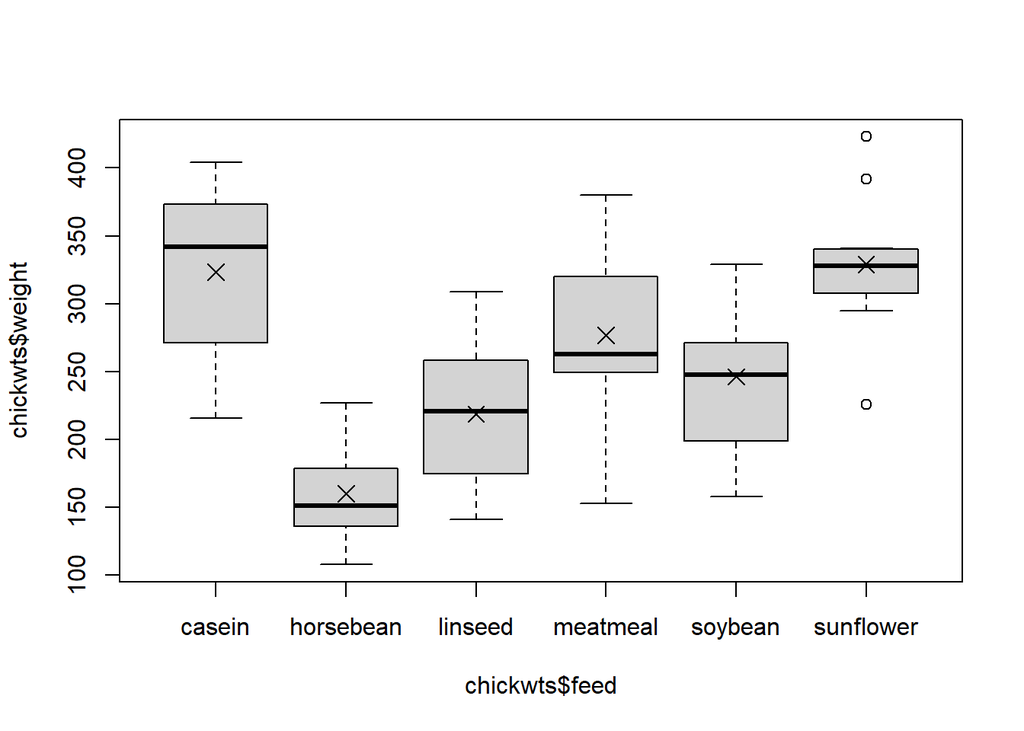

```r
boxplot(chickwts$weight~chickwts$feed)
points(1:6,chick.means,pch=4,cex=1.5)
```

Deoarece graficul boxplot arata in loc de medie valoarea mediana, ultima linie de cod adauga fiecarui box valoarea medie specifica fiecarui tip de mancare.

Analizand graficul, putem sesiza o diferenta intre mediile de greutate. Dar e vreuna dintre diferente significanta? Pentru a ne da seama, testul ANOVA se bazeaza pe urmatorele ipoteze:

**H0 : μcasein = μhorsebean = µlinseed = µmeatmeal = µsoybean = µsunflower**

**HA : Mediile nu sunt toate egale.**

Pornind de la presupunerea ca valorile sunt independente, trebuie verificate celelalte presupuneri inainte de a implementa testul. Astfel, putem examina egalitatea variatiilor folosind regula generala din cele doua teste de proba t-test. Putem valida presupunerea egalitatii variatiilor daca raportul dintre valoarea maxima si minima a variatiei standard este mai mica decat 2. Pentru greutatile puilor de gaina, urmatorul cod determina aceasta validare:

```r
chick.sds <- tapply(chickwts$weight,INDEX=chickwts$feed,FUN=sd)
chick.sds
```

```
##    casein horsebean   linseed  meatmeal   soybean sunflower
##  64.43384  38.62584  52.23570  64.90062  54.12907  48.83638
```

```r
max(chick.sds)/min(chick.sds)
```

```
## [1] 1.680238
```

Pentru validarea normalitatii, se va proceda astfel:

- se vor rearanja si replica elementele din vectorul *chick.means* pentru a corespunde elementelor din vectorul original de greutati
- se va folosi functia *as.numeric* pe fiecare valoare a *chickwts$feed* din dataframe pentru rearanjarea elementelor din *chick.means*
- se va lua vectorul original de greutati si se va scadea din el vectorul *chick.means* modificat

Diferenta va fi calculata astfel:

```r
chick.meancen <- chickwts$weight-chick.means[as.numeric(chickwts$feed)]
```

Aceste valori centrate pe medie pot fi referite si ca *reziduuri*. Reziduurile sunt folosite pentru validarea normalitatii observatiilor. In acest sens, se va analiza graficul normal QQ, pentru aceasta se vor folosi functiile *qqnorm* si *qqline*:

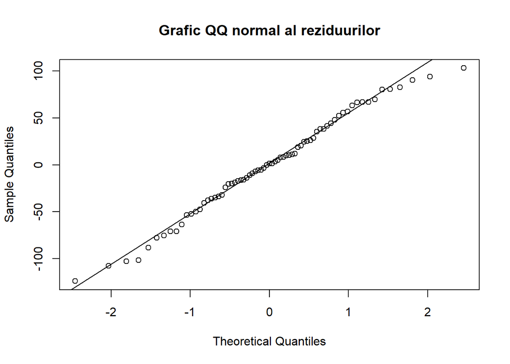

```r
qqnorm(chick.meancen,main="Grafic QQ normal al reziduurilor")
qqline(chick.meancen)
```

Bazandu-ne pe graficul de mai sus, putem afirma presupunerea de normalitate a datelor de la care am pornit.

Investigarea si validarea presupunerilor se numeste *verificarea diagnosticului*. Exista si alte ipoteze generale de testare a normalitatii, cum ar fi *testul Shapiro-Wilk* sau *testul Anderson-Darling*.

#### 8.2 Construirea tabelei prin metoda One-Way ANOVA

Testul continua prin a calcula intai metricile asociate cu variabilitatea generala si apoi calculul variabilitatii din grupuri si dintre grupuri. Toate acestea culmineaza printr-un singur test statistic si incadrarea *p-value* in ipoteza mentionata anterior. Aceste valori sunt definite de obicei intr-un tabel, dupa cum urmeaza:

- xi - xN reprezinta N observatii, indiferent de grup
- xi(j) - xn(j) reprezinta observatiile dintr-un anumit grup j = 1…k, astfel incat n1 + … + nk = N.
- *marea medie* a observatiilor este definita ca fiind media aritmetica a observatiilor

Tabelul ANOVA este apoi construit, notarile avand urmatoarea definitie:

- SS - suma patratelor
- df - grade de libertate
- MS - media patrata
- F - statistica testului F
- p - p-value

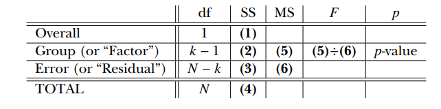

Valorile 1-6 sunt calculate cu urmatoarele formule:

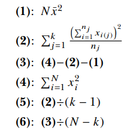

#### 8.3 Construirea tabelelor ANOVA prin intermediul functiei aov

R permite contruirea usoara a unui tabel ANOVA pentru greutatea puilor de gaina folosind functia predefinita *aov*:

```r
chick.anova <- aov(weight~feed,data=chickwts)
summary(chick.anova)
```

```
##             Df Sum Sq Mean Sq F value   Pr(>F)
## feed         5 231129   46226   15.37 5.94e-10 ***
## Residuals   65 195556    3009
## ---
## Signif. codes:  0 '***' 0.001 '**' 0.01 '*' 0.05 '.' 0.1 ' ' 1
```

Aceste rezultate se pot confirma folosind ecuatiile expuse mai devreme.

Interpretarea unei ipoteze de test bazata pe ANOVA urmareste aceleasi reguli ca oricare alt test. Cu intelegerea unui *p-value* ca *probabilitatea de a observa statisticile de proba disponibile sau daca H0 este adevarata*. O valoare mica a p-value desemneaza respingerea ipotezei nule H0 in favoarea ipotezei Ha. Ha afirma ca exista o diferenta intre mediile de greutate ale puilor de gaina atunci cand acestia au diete diferite.

#### Exercitiul 9

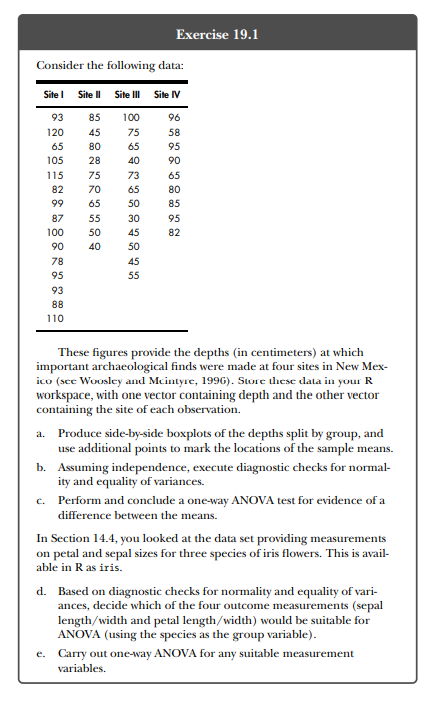

#### Exercitiul 9 - Rezolvare

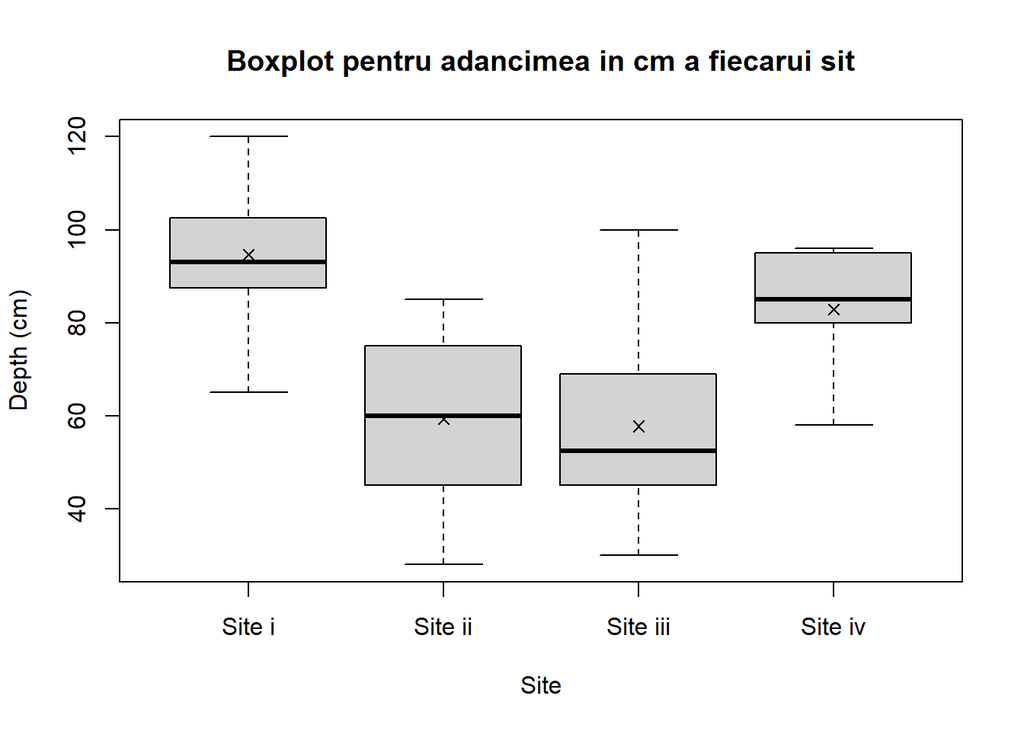

```r
info<-data.frame("dep"=c(93, 120, 65, 105, 115, 82, 99, 87, 100, 90, 78, 95, 93,
                         88, 110, 85, 45, 80, 28, 75, 70, 65, 55, 50, 40, 100,
                         75, 65, 40, 73, 65, 50, 30, 45, 50, 45, 55, 96, 58, 95,
                         90, 65, 80, 85, 95, 82),
                 "site"=c(rep("Site i",15),
                          rep("Site ii",10),
                          rep("Site iii",12),
                          rep("Site iv",9)))
# a
infomean<-tapply(info$dep,info$site,mean)

boxplot(info$dep~info$site,
        xlab="Site",
        ylab="Depth (cm)",
        main="Boxplot pentru adancimea in cm a fiecarui sit")

# Puncte aditionale
points(1:4,infomean,pch=4)
```

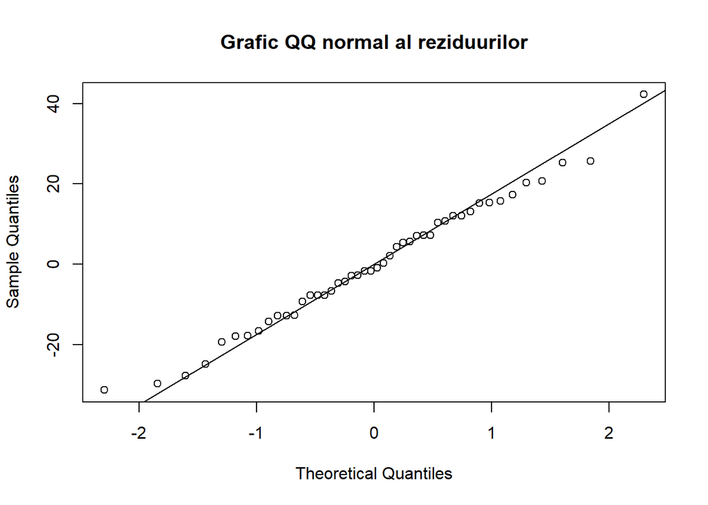

```r
# b
infomeancen <- info$dep-infomean[as.numeric(as.factor(info$site))]

qqnorm(infomeancen,main="Grafic QQ normal al reziduurilor")
qqline(infomeancen)
```

```r
# Graficul ne ofera suficiente informatii pentru a accepta normalitatea datelor

info.sds<-tapply(info$dep,info$site,sd)
max(info.sds)/min(info.sds)
```

```
## [1] 1.399928
```

```r
# Raportul dintre valoarea maxima si minima a variatiei standard este mai mica
# decat 2, deci putem accepta egalitatea variatiilor

# c
infoaov<-aov(dep~site,info)
summary(infoaov)
```

```
##             Df Sum Sq Mean Sq F value   Pr(>F)
## site         3  12397    4132   15.14 7.99e-07 ***
## Residuals   42  11465     273
## ---
## Signif. codes:  0 '***' 0.001 '**' 0.01 '*' 0.05 '.' 0.1 ' ' 1
```

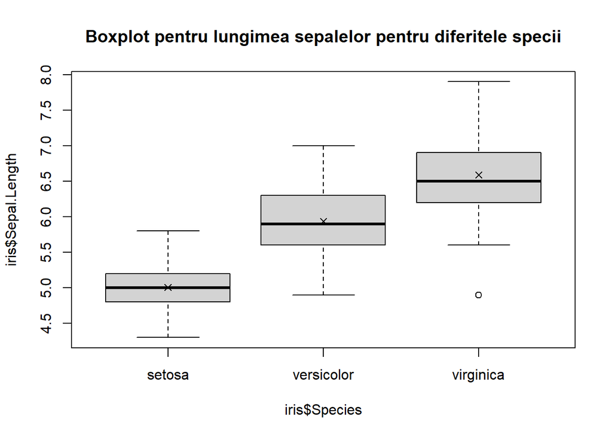

```r
# Valoarea lui p-value este foarte mica, deci putem respinge ipoteza H0

# d
# Verificarea celor 4 masuratori pentru aplicarea ANOVA

# 1) Sepal.Length

sepal_length.mean<-tapply(iris$Sepal.Length,iris$Species,mean)
sepal_length.meancen<-iris$Sepal.Length-sepal_length.mean[as.numeric(iris$Species)]
sepal_length.sd<-tapply(iris$Sepal.Length,iris$Species,sd)

# Verificarea variatiei

boxplot(iris$Sepal.Length~iris$Species, main="Boxplot pentru lungimea sepalelor pentru diferitele specii")
points(1:3,sepal_length.mean,pch=4)
```

```r
max(sepal_length.sd)/min(sepal_length.sd)
```

```
## [1] 1.803967
```

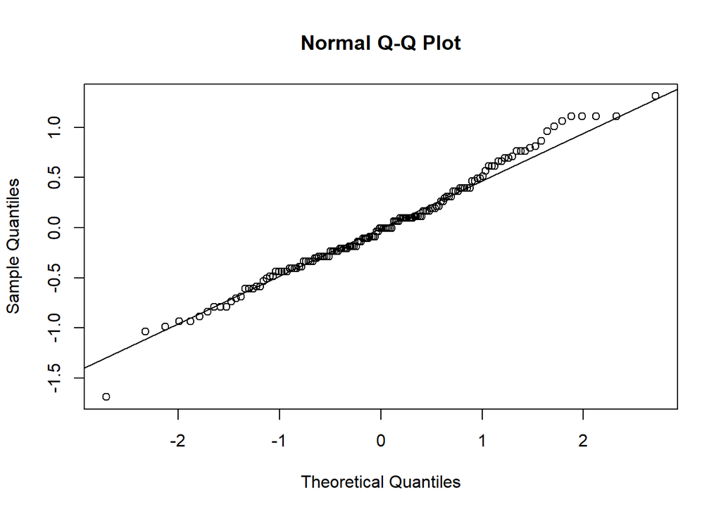

```r
# Variatia din boxplot si raportul variatiilor confirma egalitatea variatiilor

# Verificarea normalitatii

qqnorm(sepal_length.meancen)
qqline(sepal_length.meancen)
```

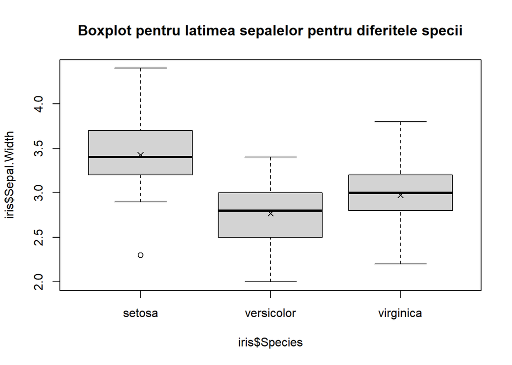

```r
# Graficul ne ofera suficiente informatii pentru a accepta normalitatea datelor
# Se poate folosi pentru analiza variantei (ANOVA)

# 2) Sepal.width

sepal_width.mean<-tapply(iris$Sepal.Width,iris$Species,mean)
sepal_width.meancen<-iris$Sepal.Width-sepal_width.mean[as.numeric(iris$Species)]
sepal_width.sd<-tapply(iris$Sepal.Width,iris$Species,sd)

# Verificarea variatiei

boxplot(iris$Sepal.Width~iris$Species, main="Boxplot pentru latimea sepalelor pentru diferitele specii")
points(1:3,sepal_width.mean,pch=4)
```

```r
max(sepal_width.sd)/min(sepal_width.sd)
```

```
## [1] 1.207987
```

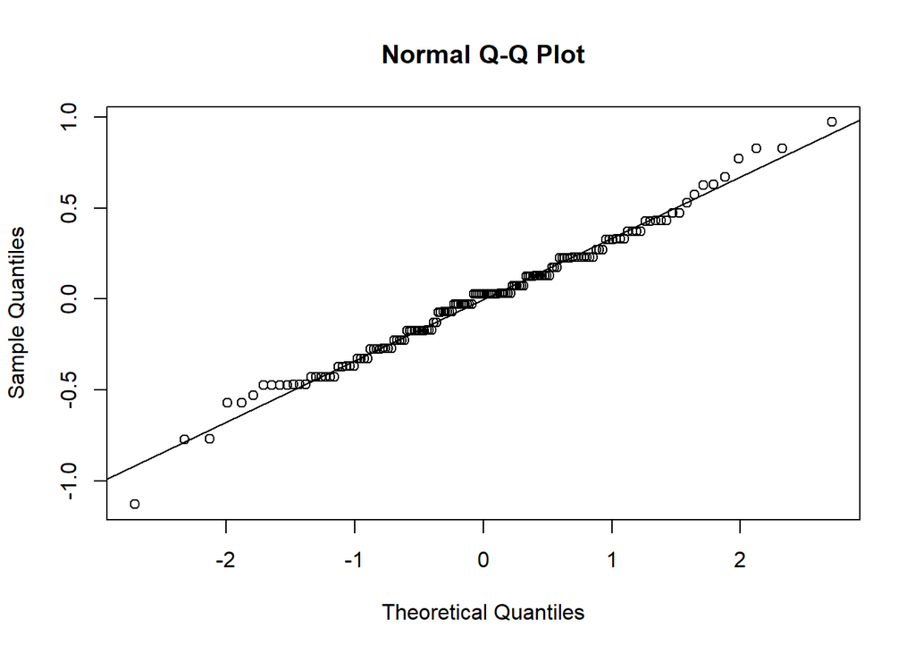

```r
# Variatia din boxplot si raportul variatiilor confirma egalitatea variatiilor

# Verificarea normalitatii

qqnorm(sepal_width.meancen)
qqline(sepal_width.meancen)
```

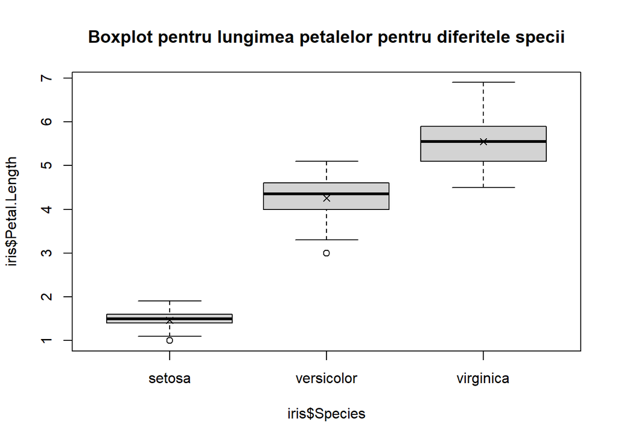

```r
# Graficul ne ofera suficiente informatii pentru a accepta normalitatea datelor.
# Aceasta distribuire este mai normala decat cea de dinainte
# Se poate folosi pentru analiza variantei (ANOVA)

# 3) Petal.Length

petal_length.mean<-tapply(iris$Petal.Length,iris$Species,mean)
petal_length.meancen<-iris$Petal.Length-petal_length.mean[as.numeric(iris$Species)]
petal_length.sd<-tapply(iris$Petal.Length,iris$Species,sd)

# Verificarea variatiei

boxplot(iris$Petal.Length~iris$Species, main="Boxplot pentru lungimea petalelor pentru diferitele specii")
points(1:3,petal_length.mean,pch=4)
```